# Identifying factors to predict math final grade

If I had a job at English First as a Business Data Analyst I hope that one of my many tasks would be to look at data that is related to students' performance and to present the information in easy to read graphs.

```python
import pandas as pd
import numpy as np
import matplotlib.pyplot as plt
import plotly
from plotly import tools
from plotly.offline import download_plotlyjs, init_notebook_mode, iplot
from plotly.graph_objs import *
init_notebook_mode()
import statsmodels.api as sm
from statsmodels.sandbox.regression.predstd import wls_prediction_std
```

## Data

[Janio Martinez](https://www.kaggle.com/janiobachmann/math-students) upload student data that was collected by Portuguese researchers in 2008. The data has many variables including a final math grade shown as 'G3'. In this brief exploration of the data I will demonstrate my ability to handle data, present data, and to make statistical inferences.

```python
data = pd.read_csv("student.csv")
```

## Missing values

Fortunately, the data has no missing values.

```python
data.isnull().sum()
```

```
school        0
sex           0
age           0
address       0
famsize       0
Pstatus       0
Medu          0
Fedu          0
Mjob          0
Fjob          0
reason        0
guardian      0
traveltime    0
studytime     0
failures      0
schoolsup     0
famsup        0
paid          0
activities    0
nursery       0
higher        0
internet      0
romantic      0
famrel        0
freetime      0
goout         0
Dalc          0
Walc          0
health        0
absences      0
G1            0
G2            0
G3            0
dtype: int64
```

## Checking for outliers

These histograms show the distribution of the various variables. The dependent variable in this analysis is 'G3'. The dependent variable is skewed to the left with many student recieving a zero as their final score. For an explanation of the other variables referer [here](https://www.kaggle.com/janiobachmann/math-students).

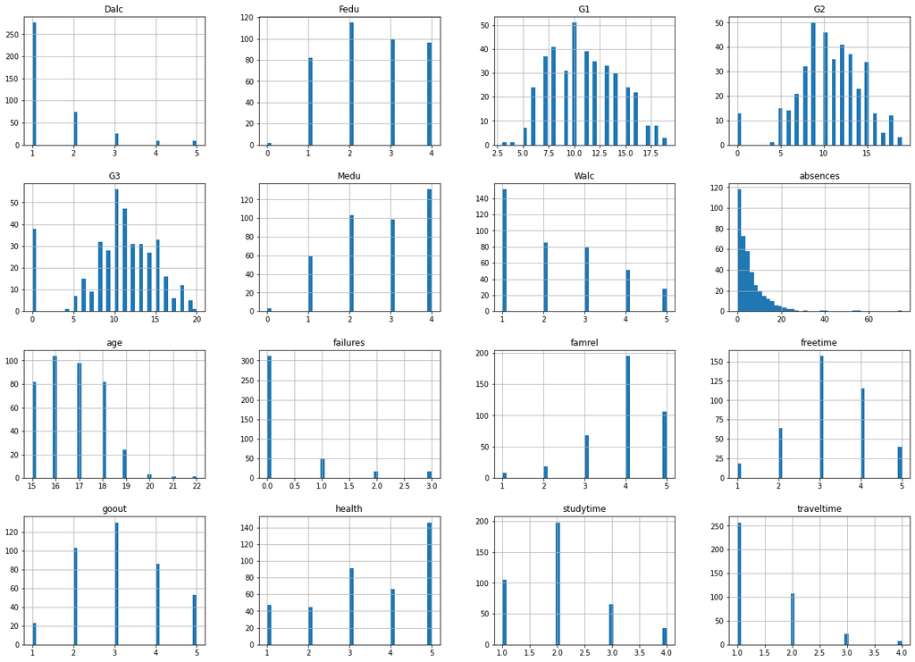

```python
data.hist(bins=40, figsize=(22,16))
plt.show()
```

## Removing highly correlated data

The data set aslo has a first period and second period grade labeled as 'G1' and 'G2'. This histogram shows that they are all highly correlated and therefore should be omitted if we want to determine what variables have the biggest effect on 'G3'.

```python
first=data.G1
second=data.G2
final=data.G3
First=Histogram(x=first,name='First Semester',text='Grades',marker=dict(color='#F79F81'))
Second=Histogram(x=second,name='Second Semester',text='Grades',marker=dict(color='#9FF781'))
Final=Histogram(x=final,name='Final Score',text='Grades',marker=dict(color='#CED8F6'))
table=[First, Second, Final]
layout=Layout(barmode='stack',title='Distribution of Grades', font=dict(size=16), xaxis=dict(title='Grades'),
             yaxis=dict(title='Number of Students'))
fig=dict(data=table,layout=layout)
iplot(fig)
```

[interactive chart not shown]

```python
data.drop(['G1','G2'],axis=1,inplace=True)
```

## Preparing data for an OLS Linear Regression

All of the 'object' variables need to be converted to an integer.

```python
data.info()
```

```
<class 'pandas.core.frame.DataFrame'>
RangeIndex: 395 entries, 0 to 394
Data columns (total 31 columns):
 #   Column      Non-Null Count  Dtype
---  ------      --------------  -----
 0   school      395 non-null    object
 1   sex         395 non-null    object
 2   age         395 non-null    int64
 3   address     395 non-null    object
 4   famsize     395 non-null    object
 5   Pstatus     395 non-null    object
 6   Medu        395 non-null    int64
 7   Fedu        395 non-null    int64
 8   Mjob        395 non-null    object
 9   Fjob        395 non-null    object
```

[output cut: 23 more lines]

## Unique values

From this output we can see which variable are binary and can be converted to one and zero, and which variable we need to make a dummy variable for.

```python
cols=data.columns
unique={col: data[col].unique() for col in cols}
unique
```

```
{'school': array(['GP', 'MS'], dtype=object),
 'sex': array(['F', 'M'], dtype=object),
 'age': array([18, 17, 15, 16, 19, 22, 20, 21], dtype=int64),
 'address': array(['U', 'R'], dtype=object),
 'famsize': array(['GT3', 'LE3'], dtype=object),
 'Pstatus': array(['A', 'T'], dtype=object),
 'Medu': array([4, 1, 3, 2, 0], dtype=int64),
 'Fedu': array([4, 1, 2, 3, 0], dtype=int64),
 'Mjob': array(['at_home', 'health', 'other', 'services', 'teacher'], dtype=object),
 'Fjob': array(['teacher', 'other', 'services', 'health', 'at_home'], dtype=object),
 'reason': array(['course', 'other', 'home', 'reputation'], dtype=object),
 'guardian': array(['mother', 'father', 'other'], dtype=object),
 'traveltime': array([2, 1, 3, 4], dtype=int64),
 'studytime': array([2, 3, 1, 4], dtype=int64),
 'failures': array([0, 3, 2, 1], dtype=int64),
 'schoolsup': array(['yes', 'no'], dtype=object),
 'famsup': array(['no', 'yes'], dtype=object),
 'paid': array(['no', 'yes'], dtype=object),
 'activities': array(['no', 'yes'], dtype=object),
 'nursery': array(['yes', 'no'], dtype=object),
 'higher': array(['yes', 'no'], dtype=object),
 'internet': array(['no', 'yes'], dtype=object),
 'romantic': array(['no', 'yes'], dtype=object),
 'famrel': array([4, 5, 3, 1, 2], dtype=int64),
 'freetime': array([3, 2, 4, 1, 5], dtype=int64),
 'goout': array([4, 3, 2, 1, 5], dtype=int64),
 'Dalc': array([1, 2, 5, 3, 4], dtype=int64),
 'Walc': array([1, 3, 2, 4, 5], dtype=int64),
 'health': array([3, 5, 1, 2, 4], dtype=int64),
 'absences': array([ 6,  4, 10,  2,  0, 16, 14,  7,  8, 25, 12, 54, 18, 26, 20, 56, 24,
        28,  5, 13, 15, 22,  3, 21,  1, 75, 30, 19,  9, 11, 38, 40, 23, 17],
       dtype=int64),
 'G3': array([ 6, 10, 15, 11, 19,  9, 12, 14, 16,  5,  8, 17, 18, 13, 20,  7,  0,
         4], dtype=int64)}
```

## Binary variables

All these variable are converted to either one or zero.

```python
data['school']=data['school'].apply(lambda x: 0 if x=='GP' else 1)
data['sex']=data['sex'].apply(lambda x: 0 if x=='F' else 1)
data['address']=data['address'].apply(lambda x: 0 if x=='U' else 1)
data['famsize']=data['famsize'].apply(lambda x: 0 if x=='GT3' else 1)
data['Pstatus']=data['Pstatus'].apply(lambda x: 0 if x=='A' else 1)
data['schoolsup']=data['schoolsup'].apply(lambda x: 0 if x=='no' else 1)
data['famsup']=data['famsup'].apply(lambda x: 0 if x=='no' else 1)
data['paid']=data['paid'].apply(lambda x: 0 if x=='no' else 1)
data['activities']=data['activities'].apply(lambda x: 0 if x=='no' else 1)
data['nursery']=data['nursery'].apply(lambda x: 0 if x=='no' else 1)
data['higher']=data['higher'].apply(lambda x: 0 if x=='no' else 1)
data['internet']=data['internet'].apply(lambda x: 0 if x=='no' else 1)
data['romantic']=data['romantic'].apply(lambda x: 0 if x=='no' else 1)
```

## Dummy variables

These variables are converted to dummy variables because they are categorical with more than two values.

```python
mom_edu=pd.get_dummies(data['Mjob']).rename(columns=lambda x: 'mom_'+str(x))
data=data.drop('Mjob', axis=1)
dad_edu=pd.get_dummies(data['Fjob']).rename(columns=lambda x: 'dad_'+str(x))
data=data.drop('Fjob', axis=1)
reason=pd.get_dummies(data['reason']).rename(columns=lambda x: 'reason='+str(x))
data=data.drop('reason', axis=1)
guardian=pd.get_dummies(data['guardian']).rename(columns=lambda x: 'guardian='+str(x))
data=data.drop('guardian',axis=1)
data=data.merge(mom_edu,left_index=True,right_index=True).merge(dad_edu,left_index=True,right_index=True)
data=data.merge(reason,left_index=True,right_index=True).merge(guardian,left_index=True,right_index=True)
```

## Correlation

```python
correlation = data.corr()
correlation['G3'].sort_values(ascending=False)
```

```
G3                   1.000000
Medu                 0.217147
higher               0.182465
Fedu                 0.152457
mom_health           0.116158
sex                  0.103456
paid                 0.101996
internet             0.098483
studytime            0.097820
reason=reputation    0.095692
dad_teacher          0.095374
famsize              0.081407
mom_services         0.078429
mom_teacher          0.057712
dad_health           0.057111
reason=other         0.052008
nursery              0.051568
famrel               0.051363
absences             0.034247
guardian=father      0.032493
guardian=mother      0.022338
activities           0.016100
freetime             0.011307
dad_at_home         -0.013385
dad_services        -0.016108
reason=home         -0.021359
famsup              -0.039157
school              -0.045017
Walc                -0.051939
dad_other           -0.053483
Dalc                -0.054660
Pstatus             -0.058009
health              -0.061335
schoolsup           -0.082788
guardian=other      -0.087774
mom_other           -0.096477
reason=course       -0.098950
address             -0.105756
mom_at_home         -0.115634
traveltime          -0.117142
romantic            -0.129970
goout               -0.132791
age                 -0.161579
failures            -0.360415
Name: G3, dtype: float64
```

## OLS Regression

The Ordinary Least Squares Regression has an adjusted R2 score of 0.196 while using every variable. After removing various non significant variables I was able to raise the adjusted R2 score to 0.216. This means that the remaining variables are able to explain over 20% of the variance of the dependent variable.

Looking at the coefficients of the independent variables we can see that 'sex' and 'romantic' both have a big effect on the on the final grade in the math course. By combining these two variable I will try to find more insight into the data.

```python
X=data.loc[:, data.columns != 'G3']
y=data['G3']
X=X.drop(['paid','internet','freetime','Walc','mom_teacher','traveltime','activities','Dalc',
         'mom_other','dad_at_home','dad_health','dad_other','dad_services','Fedu','Medu',
         'mom_at_home','guardian=other','guardian=mother','guardian=father','famrel','nursery','Pstatus',
         'reason=other','reason=home','reason=course','reason=reputation'],axis=1)
X=sm.add_constant(X)
model=sm.OLS(y,X)
results=model.fit()
print(results.summary())
```

```
                            OLS Regression Results
==============================================================================
Dep. Variable:                     G3   R-squared:                       0.250
Model:                            OLS   Adj. R-squared:                  0.216
Method:                 Least Squares   F-statistic:                     7.395
Date:                Thu, 03 Sep 2020   Prob (F-statistic):           9.34e-16
Time:                        07:25:48   Log-Likelihood:                -1104.3
No. Observations:                 395   AIC:                             2245.
Df Residuals:                     377   BIC:                             2316.
Df Model:                          17
Covariance Type:            nonrobust
================================================================================
                   coef    std err          t      P>|t|      [0.025      0.975]
--------------------------------------------------------------------------------
const           15.2952      3.554      4.304      0.000       8.307      22.284
school           0.5989      0.738      0.811      0.418      -0.853       2.051
sex              1.3276      0.451      2.946      0.003       0.441       2.214
age             -0.3307      0.194     -1.703      0.089      -0.712       0.051
address         -0.7669      0.523     -1.466      0.144      -1.796       0.262
famsize          0.5793      0.461      1.257      0.209      -0.327       1.485
studytime        0.6156      0.268      2.299      0.022       0.089       1.142
failures        -1.7615      0.304     -5.802      0.000      -2.358      -1.165
schoolsup       -1.3839      0.646     -2.142      0.033      -2.654      -0.114
famsup          -0.6946      0.440     -1.578      0.116      -1.560       0.171
higher           1.4347      1.013      1.416      0.157      -0.557       3.426
romantic        -0.9833      0.451     -2.178      0.030      -1.871      -0.096
goout           -0.4570      0.188     -2.429      0.016      -0.827      -0.087
health          -0.2269      0.151     -1.504      0.133      -0.524       0.070
absences         0.0691      0.027      2.567      0.011       0.016       0.122
mom_health       2.2829      0.760      3.004      0.003       0.789       3.777
mom_services     1.4138      0.483      2.930      0.004       0.465       2.363
dad_teacher      1.6477      0.797      2.068      0.039       0.081       3.214
==============================================================================
Omnibus:                       38.395   Durbin-Watson:                   2.069
Prob(Omnibus):                  0.000   Jarque-Bera (JB):               47.311
Skew:                          -0.776   Prob(JB):                     5.33e-11
Kurtosis:                       3.681   Cond. No.                         330.
==============================================================================

Warnings:
[1] Standard Errors assume that the covariance matrix of the errors is correctly specified.
```

## New variables for further exploration

Now we will gather the final grade for girls, boys, girls who are dating, girls who aren't dating, boys who are dating, and boys who aren't dating. Comparing these variable against each other in histograms will highlight some of the trends.

```python
girls_dating=data[(data['sex']==0) & (data['romantic']==1)]
girls_no_dating=data[(data['sex']==0) & (data['romantic']==0)]
boys_dating=data[(data['sex']==1) & (data['romantic']==1)]
boys_no_dating=data[(data['sex']==1) & (data['romantic']==0)]
boys=data[data['sex']==1]
girls=data[data['sex']==0]
dating=data[data['romantic']==1]
no_dating=data[data['romantic']==0]
girls_dating=girls_dating.G3
girls_no_dating=girls_no_dating.G3
boys_dating=boys_dating.G3
boys_no_dating=boys_no_dating.G3
boys=boys.G3
girls=girls.G3
dating=dating.G3
no_dating=no_dating.G3
```

## Boys vs Girls Count

It's worth noting that girls make up 53% of the sample size.

```python
print(len(girls)/(len(boys)+len(girls)))
```

```
0.5265822784810127
```

## Boys vs Girls Score

Girls make up 60% of those who scored 0/20, but only 50% of those who scored higher than 13/20.

```python
b=Histogram(x=boys,name='Boys',text='Grades',marker=dict(color='#1f77b4'))
g=Histogram(x=girls,name='Girls',text='Grades',marker=dict(color='#d62728'))
data=[b,g]
layout=Layout(barmode='stack',title='Boys vs Girls', font=dict(size=16), xaxis=dict(title='Grades'),
             yaxis=dict(title='Number of Students'))
fig=dict(data=data,layout=layout)
iplot(fig)
```

[interactive chart not shown]

```python
print(23/(23+15))
print((14+15+16+3+5+2)/(14+15+16+3+5+2+13+17+10+3+7+3+1))
```

```
0.6052631578947368
0.5045871559633027
```

## Girls Dating vs Girls not Dating Count

38% of the girls are in a romantic relationship.

```python
print(len(girls_dating))
print(len(girls_no_dating))
```

```
79
129
```

## Girls Dating vs Girls not Dating Score

Girls who are dating make up 65% of girls who scored 0/20, and 33% of girls who scored higher than 13/20.

```python
gnd=Histogram(x=girls_no_dating,name='Not Dating',text='Grades',marker=dict(color='#9467bd'))
gd=Histogram(x=girls_dating,name='Dating', text='Grades',marker=dict(color='#17becf'))
data=[gd,gnd]
layout=Layout(barmode='stack',title='Dating Girls vs non Dating Girls', font=dict(size=16), xaxis=dict(title='Grades'),
             yaxis=dict(title='Number of Students'))
fig=dict(data=data,layout=layout)
iplot(fig)
```

[interactive chart not shown]

```python
print((15)/(15+8))
print((12+2+1)/(12+2+1+18+7+6))
```

```
0.6521739130434783
0.32608695652173914
```

## Dating Boys vs non Dating Boys Count

28% of the boys are in a romantic relationship.

```python
print(len(boys_dating))
print(len(boys_no_dating))
```

```
53
134
```

## Dating Boys vs non Dating Boys Score

Boys who are dating make up 33% of boys who scored 0/20, and 20% of boys who scored higher than 13/20.

```python
bnd=Histogram(x=boys_no_dating,name='Not Dating',text='Grades',marker=dict(color='#e377c2'))
bd=Histogram(x=boys_dating,name='Dating',text='Grades',marker=dict(color='#ff7f0e'))
data=[bd,bnd]
layout=Layout(barmode='stack',title='Dating Boys vs non Dating Boys', font=dict(size=16), xaxis=dict(title='Grades'),
             yaxis=dict(title='Number of Students'))
fig=dict(data=data,layout=layout)
iplot(fig)
```

[interactive chart not shown]

```python
print((5)/(5+10))
print((5+6)/(5+6+25+7+10+1))
```

```
0.3333333333333333
0.2037037037037037
```

# Conclusions

## Further exploration

What are the main reasons for receiving 0/20? Why is dating having a negative impact on math scores? Why is dating having a more negative impact on girls?